# EDA Laboratório 1

## Que tal analisarmos duas séries avaliadas no IMDB?

Pois bem, as séries análisadas em questão serão duas, Breaking Bad e Silicon Valley, ambas com um número pequeno de temporadas, 5 e 4, respectivamente.

Nessa análise vamos responder duas perguntas:

Bom, antes de qualquer coisa precisamos coletar dados no IMDB sobre as séries que estamos considerando nesta análise. E para isso precisamos `coletar` de alguma forma esses dados, em nosso caso, através de uma arquivo `series_from_imdb.csv` que contém dados sobre todas as serias avaliadas no IMDB.

```r
series = read_csv(here("data/series_from_imdb.csv"),
                    progress = FALSE,
                    col_types = cols(.default = col_double(),
                                     series_name = col_character(),
                                     episode = col_character(),
                                     url = col_character(),
                                     season = col_character()))
series = series %>%
    filter(series_name %in% c("Breaking Bad", "Silicon Valley")) %>%
    group_by(series_name, season) %>%
    mutate(medias_temporada = mean(user_rating))
```

Note que, para essa análise, filtramos de todos os dados apenas os que nos enteressa nesse momento, `Breaking Bad` e `Silicon Valey`

### Um sumário inicial dos dados

A tabela abaixo sumariza as temporadas de ambas as series mostrando números importantes para considerarmos nesta análise. Podemos observar para cada temporada (coluna `season`) a menor e maior avaliação (`min_rating` e `max_rating` respectivamente), a média de avaliação de cada temporada (`average`) como também algumas coisas importantes como variância (`variance`) e desvio padrão (`sd`).

```r
summary = series %>%
    group_by(season, series_name) %>%
    summarize(
        min_rating = min(user_rating),
        max_rating = max(user_rating),
        average = mean(user_rating),
        variance = var(user_rating),
        sd = sd(user_rating))
summary
```

| season | series_name | min_rating | max_rating | average | variance | sd |
| --- | --- | --- | --- | --- | --- | --- |
| 1 | Breaking Bad | 8.3 | 9.2 | 8.728571 | 0.09904762 | 0.3147183 |
| 1 | Silicon Valley | 7.8 | 9.4 | 8.337500 | 0.27410714 | 0.5235524 |
| 2 | Breaking Bad | 8.3 | 9.2 | 8.815385 | 0.10474359 | 0.3236411 |
| 2 | Silicon Valley | 8.0 | 9.3 | 8.490000 | 0.16766667 | 0.4094712 |
| 3 | Breaking Bad | 7.7 | 9.6 | 8.784615 | 0.30474359 | 0.5520359 |
| 3 | Silicon Valley | 8.1 | 8.8 | 8.450000 | 0.05833333 | 0.2415229 |
| 4 | Breaking Bad | 8.1 | 9.9 | 9.000000 | 0.29333333 | 0.5416026 |
| 4 | Silicon Valley | 8.1 | 8.7 | 8.383333 | 0.06966667 | 0.2639444 |
| 5 | Breaking Bad | 8.8 | 9.9 | 9.375000 | 0.13533333 | 0.3678768 |

# Perguntas

## Qual série é melhor avaliada no IMDB?

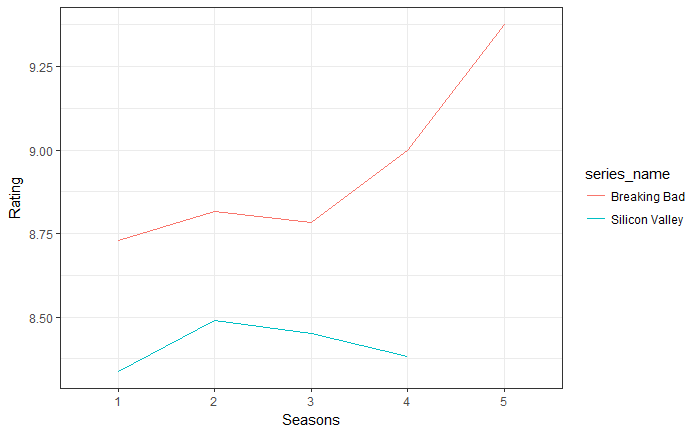

```r
ggplot(series, aes(x = season, y = medias_temporada, label = season, color = series_name, group = series_name)) +
    geom_line() +
    labs(x = "Seasons", y = "Rating")
```

O gráfico acima mostra que a série Breaking Bad é melhor avaliada, em relação a série Silicon Valley, em todas as suas temporadas. Além disso, é possível notar que, no caso de Breaking Bad, as notas de avaliação foram aumentando ao longo das temporadas, situação muito distinta para silicon valley, que diminui sua nota de avalição a partir da segunda temporada. As notas de avaiação para a série Breaking Bad variam bastante ao longo das temporadas, com tentencia de crescimento, enquanto que Silicon Valley possui pouca variação. Dessa forma, e com apoio da visualização gráfica, a diferença de avaliação entre as séries é grande. Portanto, a série melhor avaliada é Breaking Bad.

## Qual das séries que você escolheu tem episódios de qualidade mais irregular segundo o IMDB? A diferença é grande? Pequena?

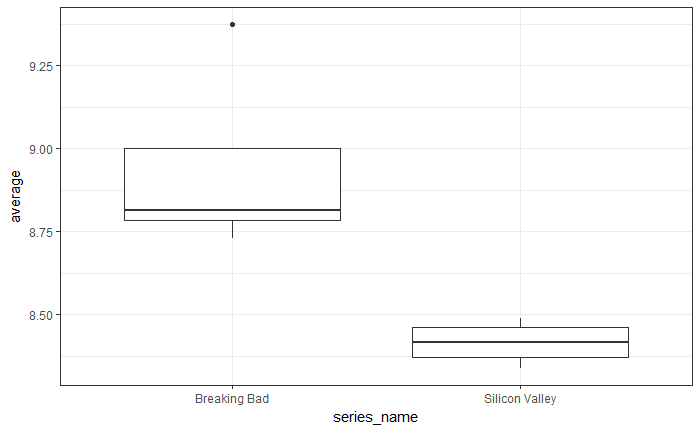

Como é possível observar no gráfico acima, para a série Breaking Bad o mediana está bem próximo do primeiro quartil, indicando maior irregularidade no valor de avaliação média dentre suas cinco temporadas. Quando observado a série Silicon valley vemos que a mediana está no centro, isto é, representando uma média central nos 50% das médias de avaliação de suas quatro temporadas, ou seja, possuindo pouca irregularidade. Dessa forma, a séria Breaking Bad possui maior irregularidade quanto aos seus episódios, segundo o IMDB, quando comparada a série Silicon Valley.